# IE - Master in Business Analytics and Big Data

Recommendation Systems

Building a Non Personalized Recommendation Engine

Author: Annie Pi / Last Updated: Feb. 13, 2018

========================================================

# Initialization

Import libraries

```r
library(dplyr) #for chained manipulations and calculations
library(ggplot2) #for data visualization
library(stringr) #for string manipulations
```

Load the critics dataset and explore structure.

```r
critics <- read.csv("critics.csv")
str(critics)
```

```
## 'data.frame':    20 obs. of  21 variables:
##  $ User                             : Factor w/ 20 levels "Ana","Anton",..: 8 10 2 17 11 1 18 9 7 5 ...
##  $ Star.Wars.IV...A.New.Hope        : int  1 5 NA NA 4 2 NA 4 5 4 ...
##  $ Star.Wars.VI...Return.of.the.Jedi: int  5 3 NA 3 3 4 NA NA 1 2 ...
##  $ Forrest.Gump                     : int  2 NA NA NA 4 4 3 NA NA NA ...
##  $ The.Shawshank.Redemption         : int  NA 2 5 NA 1 4 1 NA 4 5 ...
##  $ The.Silence.of.the.Lambs         : int  4 4 2 NA 4 NA 1 3 2 3 ...
##  $ Gladiator                        : int  4 2 NA 1 1 NA 4 2 4 NA ...
##  $ Toy.Story                        : int  2 1 4 2 NA 3 NA 2 4 4 ...
##  $ Saving.Private.Ryan              : int  2 NA NA 3 4 1 5 NA 4 3 ...
##  $ Pulp.Fiction                     : int  NA NA NA 4 NA 4 2 3 NA 4 ...
##  $ Stand.by.Me                      : int  3 4 1 NA 1 4 NA NA 1 NA ...
##  $ Shakespeare.in.Love              : int  2 3 NA NA 5 5 1 NA 2 NA ...
##  $ Total.Recall                     : int  NA 2 1 4 1 2 NA 2 3 NA ...
##  $ Independence.Day                 : int  5 2 4 1 NA 4 NA 3 1 2 ...
##  $ Blade.Runner                     : int  2 NA 4 3 4 NA 3 2 NA NA ...
##  $ Groundhog.Day                    : int  NA 2 1 5 NA 1 NA 4 5 NA ...
##  $ The.Matrix                       : int  4 NA 1 NA 3 NA 1 NA NA 2 ...
##  $ Schindler.s.List                 : int  2 5 2 5 5 NA NA 1 NA 5 ...
##  $ The.Sixth.Sense                  : int  5 1 3 1 5 3 NA 3 NA 1 ...
##  $ Raiders.of.the.Lost.Ark          : int  NA 3 1 1 NA NA 5 5 NA NA ...
##  $ Babe                             : int  NA NA 3 2 NA 2 2 NA 5 NA ...
```

Before beginning analysis, I want to fix the column/movie names to replace periods.

```r
#loop through column names, replacing "..." with " - " and "." with " "
for(i in 2:ncol(critics)) {
  colnames(critics)[i] = gsub("\\.", " ", gsub("\\.\\.\\.", " - ", colnames(critics)[i],))
}

#display updated column names
colnames(critics)
```

```
##  [1] "User"
##  [2] "Star Wars IV - A New Hope"
##  [3] "Star Wars VI - Return of the Jedi"
##  [4] "Forrest Gump"
##  [5] "The Shawshank Redemption"
##  [6] "The Silence of the Lambs"
##  [7] "Gladiator"
##  [8] "Toy Story"
##  [9] "Saving Private Ryan"
## [10] "Pulp Fiction"
## [11] "Stand by Me"
## [12] "Shakespeare in Love"
## [13] "Total Recall"
## [14] "Independence Day"
## [15] "Blade Runner"
## [16] "Groundhog Day"
## [17] "The Matrix"
## [18] "Schindler s List"
## [19] "The Sixth Sense"
## [20] "Raiders of the Lost Ark"
## [21] "Babe"
```

# 1) Top 5 Movies, by rating mean

Calculate mean rating for each movie, ordered with the highest rating listed first, and plot the top 5.

**Expected result**: 3.600000, ‘The Shawshank Redemption’ 3.266667, ‘Star Wars IV - A New Hope’ 3.222222, ‘Blade Runner’ 3.166667, ‘Groundhog Day’ 3.062500, ‘The Silence of the Lambs’

```r
#create a data frame of calculated column means for each Movie column (excluding the first one, which is User)
avgRatings = data.frame(colMeans(critics[,-1], na.rm=T))

#set column names for the data frame
avgRatings = setNames(cbind(rownames(avgRatings), avgRatings, row.names = NULL),
         c("MovieName", "AvgRating"))

#arrange ratings in descending order
avgRatings = avgRatings %>%
  arrange(desc(AvgRating))

#display top 5 average ratings
avgRatings %>%
  head(5) %>%
  select(AvgRating, MovieName)
```

```
##   AvgRating                 MovieName
## 1  3.600000  The Shawshank Redemption
## 2  3.266667 Star Wars IV - A New Hope
## 3  3.222222              Blade Runner
## 4  3.166667             Groundhog Day
## 5  3.062500  The Silence of the Lambs
```

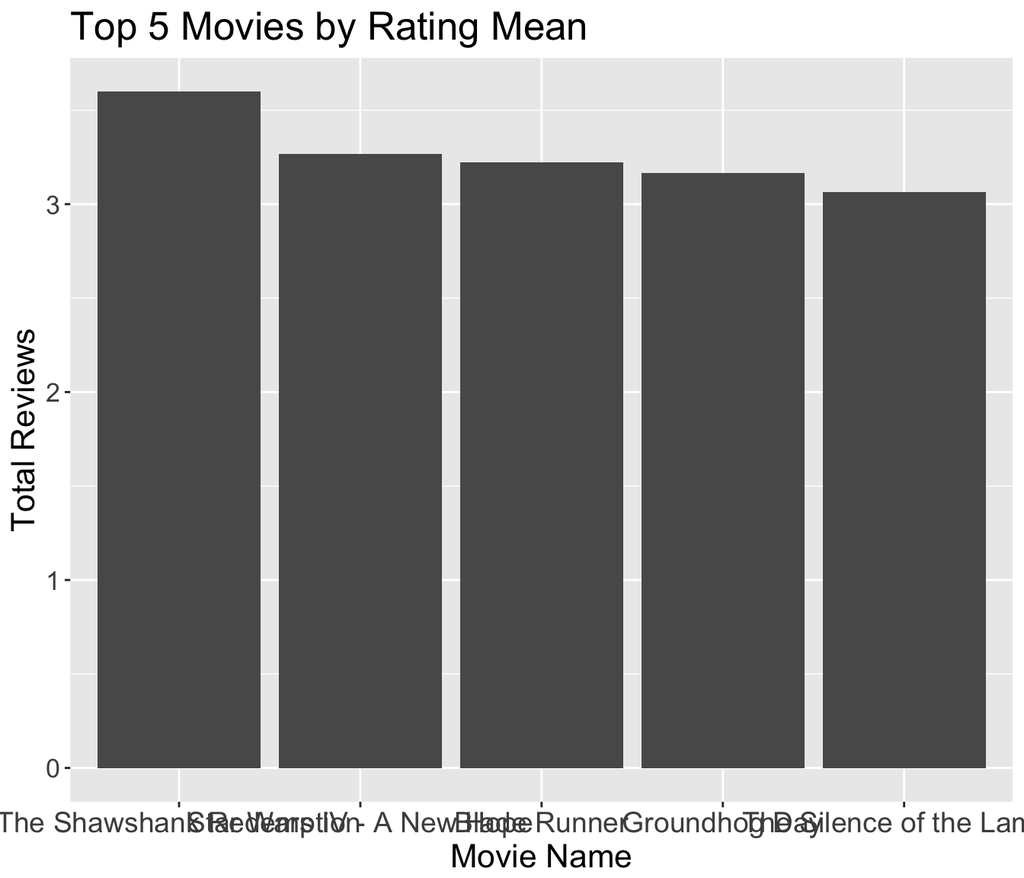

```r
#create a bar graph of top 5 movies by rating and re-arrange bars to show in descending order
avgRatings %>%
  head(5) %>%
  ggplot(aes(x=factor(MovieName, levels=avgRatings$MovieName[order(desc(avgRatings$AvgRating))]), y=AvgRating)) +
  geom_bar(stat="identity") +
  theme(axis.text.x = element_text(size=14), text = element_text(size=16)) +
  labs(x="Movie Name", y="Total Reviews", title="Top 5 Movies by Rating Mean")
```

# 2) Top 5 Movies, by rating distribution

Calculate the percentage of ratings for each movie that are 4 stars or higher. Order with the highest percentage first, and plot the top 5 movies with more high ratings distribution.

**Expected result**: 0.7000000, ‘The Shawshank Redemption’ 0.5333333, ‘Star Wars IV - A New Hope’ 0.5000000, ‘Gladiator’ 0.4444444, ‘Blade Runner’ 0.4375000, ‘The Silence of the Lambs’

```r
#create an empty data frame to store ratings
highRatings <- data.frame()

#loop through all rows for all columns to calculate a running sum of number of ratings greater than 4
for(i in 2:ncol(critics)) {
  sum.x <- 0
  for(j in 1:nrow(critics)) {
    if(is.na(critics[j,i]) == FALSE && critics[j,i] >= 4) {
      sum.x <- sum.x + 1
    }
  }
  highRatings <- rbind(highRatings, sum.x/sum(!is.na(critics[i]))) #for each film, calculate number of ratings greater than 4 divided by total number of ratings and add this to the data frame
}

#set column names for the data frame
highRatings2 = setNames(cbind(colnames(critics[2:21]), highRatings, row.names = NULL),
  c("MovieName", "HighRatingPct"))

#arrange in descending order
highRatings2 = highRatings2 %>%
  arrange(desc(HighRatingPct)) %>%
  select(HighRatingPct, MovieName)

#display ratings
highRatings2 %>%
  head(5)
```

```
##   HighRatingPct                 MovieName
## 1     0.7000000  The Shawshank Redemption
## 2     0.5333333 Star Wars IV - A New Hope
## 3     0.5000000                 Gladiator
## 4     0.4444444              Blade Runner
## 5     0.4375000  The Silence of the Lambs
```

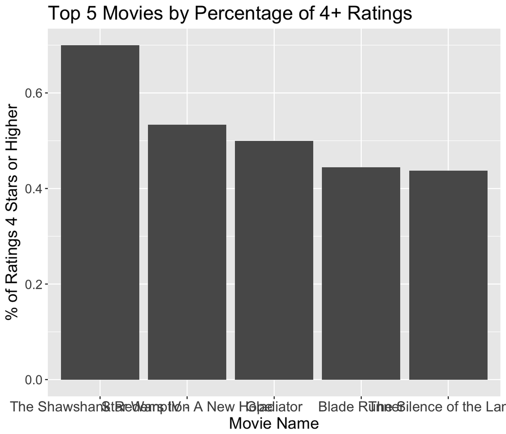

```r
#create a bar graph of top 5 movies by percentage of high ratings
highRatings2 %>%
  head(5) %>%
  ggplot(aes(x=factor(MovieName, levels=highRatings2$MovieName[order(desc(highRatings2$HighRatingPct))]), y=HighRatingPct)) +
  geom_bar(stat="identity") +
  theme(axis.text.x = element_text(size=14), text = element_text(size=16)) +
  labs(x="Movie Name", y="% of Ratings 4 Stars or Higher", title="Top 5 Movies by Percentage of 4+ Ratings")
```

# 3) Top 5 Movies, by quantity of ratings

Count the number of ratings for each movie, order the one with most number of ratings first, submit the top 5.

**Expected result**: 17, ‘Toy Story’ 16, ‘The Silence of the Lambs’ 15, ‘Star Wars IV - A New Hope’ 14, ‘Star Wars VI - Return of the Jedi’ 13, ‘Independence Day’

```r
#create an empty data frame
numRatings <- data.frame()

#loop through each column (movie) and add a count of ratings for each mavie to the dataframe
for(i in 2:ncol(critics)) {
  numRatings <- rbind(numRatings, sum(!is.na(critics[i])))
}

#set column names for the data frame
numRatings2 = setNames(cbind(colnames(critics[2:21]), numRatings, row.names = NULL),
  c("MovieName", "NumRatings"))

#sort by number of ratings and show movie names for top 5
numRatings2 %>%
  arrange(desc(NumRatings)) %>%
  select(MovieName) %>%
  head(5)
```

```
##                           MovieName
## 1                         Toy Story
## 2          The Silence of the Lambs
## 3         Star Wars IV - A New Hope
## 4 Star Wars VI - Return of the Jedi
## 5                  Independence Day
```

# 4) People who watched Star Wars IV also watched …

Calculate movies that most often occur with other movie. For each movie, calculate the percentage of the other movie raters who also rated that movie. Order with the highest percentage first, and submit the top 5. Select “Star.Wars.IV…A.New.Hope” movie by defaut. Use the (x+y)/x method.

Top Occurences: 0.9333333, ‘Toy Story’ 0.8666667, ‘Star Wars: Episode VI - Return of the Jedi’ 0.8000000, ‘The Silence of the Lambs’ 0.7333333, ‘Independence Day’ 0.6666667, ‘Total Recall’

```r
#store total num of ratings for Star Wars IV - A New Hope
count = sum(!is.na(critics$`Star Wars IV - A New Hope`))

#filter on existing ratings for Star Wars IV and calculate how many ratings there are for each other film
starwars = critics %>%
  filter(!is.na(`Star Wars IV - A New Hope`)) %>%
  summarize_all(funs((sum(!is.na(.)))/count)) %>%
  select(., -User) %>% #remove User column from results
  t(.) #transpose results

#transform results into a dataframe
starwars2 = data.frame(starwars)

#set column names for the dataframe
starwars2 = setNames(cbind(rownames(starwars2), starwars2, row.names = NULL),
  c("MovieName", "Occurrences"))

#arrange by descending, remove Star Wars IV - A New Hope, and select top 5 results
starwars2 %>%
  arrange(desc(Occurrences)) %>%
  filter(MovieName != "Star Wars IV - A New Hope") %>%
  head(5) %>%
  select(Occurrences, MovieName)
```

```
##   Occurrences                         MovieName
## 1   0.9333333                         Toy Story
## 2   0.8666667 Star Wars VI - Return of the Jedi
## 3   0.8000000          The Silence of the Lambs
## 4   0.7333333                  Independence Day
## 5   0.6666667                      Total Recall
```

# 5) People who liked Babe also liked …

Calculate the movies better rated of people who liked a movie. Select the people who liked the movie “Babe” (4 or 5 stars) and provide the top 5 movies they liked most.

**Expected result**: 5.000, ‘Pulp.Fiction’ 5.000, ‘Groundhog.Day’ 4.500, ‘The.Shawshank.Redemption’ 4.333, ‘Toy.Story’ 4.000, ‘Blade.Runner’

```r
#of the users that rated Babe 4 or higher, calculate the mean ratings for other movies
babe = critics %>%
  filter(Babe >= 4) %>%
  summarize_all(funs(mean(., na.rm = T))) %>%
  select(., -User) %>%
  t(.)
#transform results into a dataframe
babe2 = data.frame(babe)

#set column names for the dataframe
babe2 = setNames(cbind(rownames(babe2), babe2, row.names = NULL),
  c("MovieName", "AvgRating"))

#arrange by descending, remove Babe, and select top 5
babe2 %>%
  arrange(desc(AvgRating)) %>%
  filter(MovieName != "Babe") %>%
  head(5) %>%
  select(AvgRating, MovieName)
```

```
##   AvgRating                MovieName
## 1  5.000000             Pulp Fiction
## 2  5.000000            Groundhog Day
## 3  4.500000 The Shawshank Redemption
## 4  4.333333                Toy Story
## 5  4.000000             Blade Runner
```

# 6) MovieLens

Explore a real data set and provide non-personalized ratings. You can use the MovieLens database. You can find MovieLens’ dataset here: http://files.grouplens.org/datasets/movielens/ml-10m-README.html

I load two datasets from MovieLens, Movies and Ratings, and create a merged dataset based on movieId so that I can access these in the same data frame.

```r
movies <- read.csv("movies.csv")
ratings <- read.csv("ratings.csv")

movielens = merge(movies, ratings, by="movieId")
```

Looking at the structure of my merged dataset, I see that there are 6 variables with 100,004 observations (ratings) and 9123 titles (movies). I notice immediately that there are several issues with the data:

- The title field contains both the name of the movie and the release year
- There are over 900 different genres
- The timestamp is in Unix format

```r
str(movielens)
```

```
## 'data.frame':    100004 obs. of  6 variables:
##  $ movieId  : int  1 1 1 1 1 1 1 1 1 1 ...
##  $ title    : Factor w/ 9123 levels "¡Three Amigos! (1986)",..: 8301 8301 8301 8301 8301 8301 8301 8301 8301 8301 ...
##  $ genres   : Factor w/ 902 levels "(no genres listed)",..: 329 329 329 329 329 329 329 329 329 329 ...
##  $ userId   : int  23 623 559 306 361 357 321 560 531 73 ...
##  $ rating   : num  3 4.5 4 3 3 5 3 4.5 3 5 ...
##  $ timestamp: int  1148729853 1225256593 903143238 956083012 864050973 832768614 939420838 1452849340 1240402247 1303464840 ...
```

It seems that the release year always comes in parentheses at the end, so I use the stringr library to extract the last six characters of the title field and insert that into a new column called releaseyear.

```r
#put last six characters into a new field called releaseyear
movielens = movielens %>%
  mutate(releaseyear = as.integer(gsub("\\)","",gsub("\\(", "", str_sub(title, start = -6)))))
movielens %>%
  dplyr::select(title,releaseyear) %>%
  head(10)
```

```
##               title releaseyear
## 1  Toy Story (1995)        1995
## 2  Toy Story (1995)        1995
## 3  Toy Story (1995)        1995
## 4  Toy Story (1995)        1995
## 5  Toy Story (1995)        1995
## 6  Toy Story (1995)        1995
## 7  Toy Story (1995)        1995
## 8  Toy Story (1995)        1995
## 9  Toy Story (1995)        1995
## 10 Toy Story (1995)        1995
```

To check that releaseyear was created correctly, I do a summary of this new column and I see that there are a few issues: the minimum is -1979 and there are 4 NAs value.

```r
summary(movielens$releaseyear)
```

```
##    Min. 1st Qu.  Median    Mean 3rd Qu.    Max.    NA's
##   -1979    1987    1995    1992    2001    2016       4
```

I inspect these values in the dataframe.

```r
movielens[movielens$releaseyear==-1979,]
```

```
##       movieId                     title genres userId rating  timestamp
## NA         NA                      <NA>   <NA>     NA     NA         NA
## 98385  108583 Fawlty Towers (1975-1979) Comedy    615    5.0 1425504620
## 98386  108583 Fawlty Towers (1975-1979) Comedy     73    5.0 1435472609
## 98387  108583 Fawlty Towers (1975-1979) Comedy    262    2.5 1433899163
## NA.1       NA                      <NA>   <NA>     NA     NA         NA
## NA.2       NA                      <NA>   <NA>     NA     NA         NA
## NA.3       NA                      <NA>   <NA>     NA     NA         NA
##       releaseyear
## NA             NA
## 98385       -1979
## 98386       -1979
## 98387       -1979
## NA.1           NA
## NA.2           NA
## NA.3           NA
```

```r
movielens[is.na(movielens$releaseyear),]
```

```
##        movieId                        title             genres userId
## 98383   108548 Big Bang Theory, The (2007-)             Comedy    270
## 99864   143410                   Hyena Road (no genres listed)    624
## 99930   151307    The Lovers and the Despot (no genres listed)    547
## 100001  162376              Stranger Things              Drama     73
##        rating  timestamp releaseyear
## 98383     3.0 1469278482          NA
## 99864     2.0 1474224802          NA
## 99930     4.5 1472400501          NA
## 100001    4.5 1474255532          NA
```

First, I see that “-1979” was parsed from “Falty Towers (1975-1979).” It seems strange that a movie would have lasted four years, and looking up this title online, I see it is actually a TV show. For the N/A values I see again there is a TV show “Big Bang Theory, The (2007-)” as well as three titles with no year at the end. I remove these rows to clean up the data.

```r
#remove values
movielens = movielens[!movielens$releaseyear==-1979,]
movielens = movielens[!is.na(movielens$releaseyear),]
```

Now there are no NA values and the years range from 1902 to 2016 and I can use this to analyze most popular movies by different years.

```r
summary(movielens$releaseyear)
```

```
##    Min. 1st Qu.  Median    Mean 3rd Qu.    Max.
##    1902    1987    1995    1992    2001    2016
```

To correct the timestamp, I use the anytime library to convert from UNIX into a datetime. Now I can parse out year if I wanted to filter only on recent reviews, for example.

```r
library(anytime)
movielens$timestamp = anytime(movielens$timestamp)

movielens %>%
  dplyr::select(timestamp) %>%
  head(5)
```

```
##             timestamp
## 1 2006-05-27 13:37:33
## 2 2008-10-29 06:03:13
## 3 1998-08-15 03:07:18
## 4 2000-04-18 20:36:52
## 5 1997-05-19 16:09:33
```

Looking at genre, I see that there are a wide combination of genres, ranging from single values “Comedy” and “Action” to concatenated genres “Adventure|Children|Fantasy.” I could split these values and perhaps pick a primary genre and then subgenres, but because this is only for a non-personalized recommendation engine, and I will make recommendations based on factors such as quantity of ratings and average rating, rather than genre, I leave the field as it is.

```r
movielens %>%
  select(genres) %>%
  distinct() %>%
  head(10)
```

```
##                                         genres
## 1  Adventure|Animation|Children|Comedy|Fantasy
## 2                   Adventure|Children|Fantasy
## 3                               Comedy|Romance
## 4                         Comedy|Drama|Romance
## 5                                       Comedy
## 6                        Action|Crime|Thriller
## 7                           Adventure|Children
## 8                                       Action
## 9                    Action|Adventure|Thriller
## 10                               Comedy|Horror
```

Next, I check for missing values across all columns, and see that there are no missing values.

```r
which(colSums(is.na(movielens)) > 0)
```

```
## named integer(0)
```

Now, looking at a summary of the data, I can see that: - Ratings range from 0.5 to 5, with a mean rating of 3.544 and a median rating of 4. - Ratings were collected from 1995 to 2016. - The most popular movies have over 300 ratings each. - Dramas are the most popular genre in the datset, followed by comedies.

```r
summary(movielens)
```

```
##     movieId                                             title
##  Min.   :     1   Forrest Gump (1994)                      :  341
##  1st Qu.:  1028   Pulp Fiction (1994)                      :  324
##  Median :  2406   Shawshank Redemption, The (1994)         :  311
##  Mean   : 12541   Silence of the Lambs, The (1991)         :  304
##  3rd Qu.:  5418   Star Wars: Episode IV - A New Hope (1977):  291
##  Max.   :163949   Jurassic Park (1993)                     :  274
##                   (Other)                                  :98152
##                   genres          userId        rating
##  Drama               : 7756   Min.   :  1   Min.   :0.500
##  Comedy              : 6744   1st Qu.:182   1st Qu.:3.000
##  Comedy|Romance      : 3973   Median :367   Median :4.000
##  Drama|Romance       : 3462   Mean   :347   Mean   :3.544
##  Comedy|Drama        : 3272   3rd Qu.:520   3rd Qu.:4.000
##  Comedy|Drama|Romance: 3204   Max.   :671   Max.   :5.000
##  (Other)             :71586
##    timestamp                    releaseyear
##  Min.   :1995-01-09 12:46:49   Min.   :1902
##  1st Qu.:2000-08-09 21:00:19   1st Qu.:1987
##  Median :2005-03-10 03:30:01   Median :1995
##  Mean   :2005-10-18 08:18:30   Mean   :1992
##  3rd Qu.:2011-01-28 06:26:44   3rd Qu.:2001
##  Max.   :2016-10-16 19:57:24   Max.   :2016
##
```

I conclude that overall, the movies in this dataset are pretty popular!

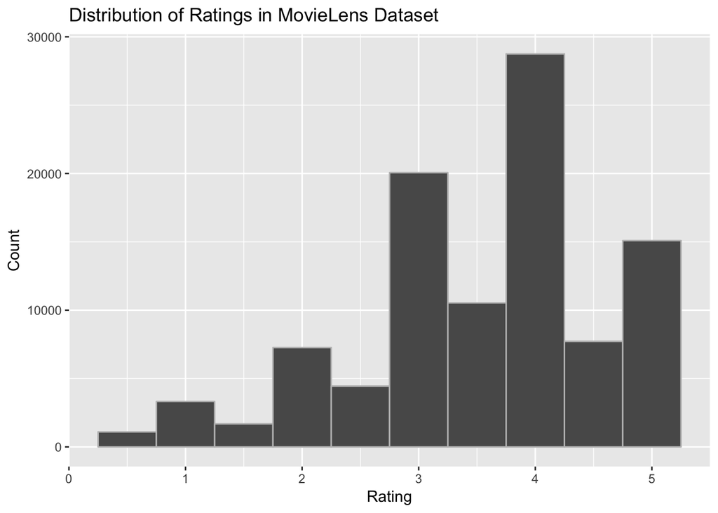

```r
ggplot(movielens, aes(x = rating)) +
  geom_histogram(bins = 10, color=I("gray")) +
  labs(x="Rating", y="Count", title="Distribution of Ratings in MovieLens Dataset")
```

To make a non-personalized recommendation using this dataset, I start by trying to select the top 10 movies, based on the average rating.

```r
movielens %>%
  group_by(title) %>%
  summarize(avgRating = mean(rating)) %>%
  arrange(desc(avgRating)) %>%
  head(10)
```

```
## # A tibble: 10 x 2
##                                title avgRating
##                               <fctr>     <dbl>
##  1              'night Mother (1986)         5
##  2               10 Attitudes (2001)         5
##  3                  16 Wishes (2010)         5
##  4               29th and Gay (2005)         5
##  5      3 Women (Three Women) (1977)         5
##  6              Above the Law (1988)         5
##  7          Absolute Giganten (1999)         5
##  8 Alaska: Spirit of the Wild (1997)         5
##  9               Albert Nobbs (2011)         5
## 10               Alien Escape (1995)         5
```

The top 10 movies all have a average rating of 5. It seems unlikely that everyone that watched the movie gave it a perfect score, unless only 1 or 2 people rated the movie. So I re-run the same analysis, but this time showing the number of reviews for each movie.

```r
movielens %>%
  group_by(title) %>%
  summarize(avgRating = mean(rating), numRatings = n()) %>%
  arrange(desc(avgRating)) %>%
  head(10)
```

```
## # A tibble: 10 x 3
##                                title avgRating numRatings
##                               <fctr>     <dbl>      <int>
##  1              'night Mother (1986)         5          3
##  2               10 Attitudes (2001)         5          1
##  3                  16 Wishes (2010)         5          1
##  4               29th and Gay (2005)         5          1
##  5      3 Women (Three Women) (1977)         5          1
##  6              Above the Law (1988)         5          1
##  7          Absolute Giganten (1999)         5          1
##  8 Alaska: Spirit of the Wild (1997)         5          1
##  9               Albert Nobbs (2011)         5          1
## 10               Alien Escape (1995)         5          1
```

As expected, the top movies are those with only 1 or 3 ratings. I don’t want to bias the results towards movies that have few ratings, so I filter for movies that only have a number of ratings greater than or equal to the mean.

```r
topRatings = movielens %>%
  group_by(title) %>%
  summarize(avgRating = mean(rating), numRatings = n()) %>%
  arrange(desc(avgRating))

topRatings %>%
  filter(numRatings >= mean(topRatings$numRatings)) %>%
  head(10)
```

```
## # A tibble: 10 x 3
##                               title avgRating numRatings
##                              <fctr>     <dbl>      <int>
##  1          Inherit the Wind (1960)  4.541667         12
##  2            Godfather, The (1972)  4.487500        200
##  3 Shawshank Redemption, The (1994)  4.487138        311
##  4                 Tom Jones (1963)  4.458333         12
##  5         On the Waterfront (1954)  4.448276         29
##  6        When We Were Kings (1996)  4.437500         16
##  7             All About Eve (1950)  4.434211         38
##  8                       Ran (1985)  4.423077         26
##  9        African Queen, The (1951)  4.420000         50
## 10            Mister Roberts (1955)  4.411765         17
```

The previous table still seems to recommend lesser-known movies from many years ago, such as “Inherit the Wind” and “Tom Jones,” so I adjust the recommendations to first select the top 10 most rated movies, and then sort by rating. This gives me the most popular films by quantity and rating.

```r
topRatings %>%
  arrange(desc(numRatings)) %>%
  head(10) %>%
  arrange(desc(avgRating))
```

```
## # A tibble: 10 x 3
##                                        title avgRating numRatings
##                                       <fctr>     <dbl>      <int>
##  1          Shawshank Redemption, The (1994)  4.487138        311
##  2                   Schindler's List (1993)  4.303279        244
##  3                       Pulp Fiction (1994)  4.256173        324
##  4 Star Wars: Episode IV - A New Hope (1977)  4.221649        291
##  5                        Matrix, The (1999)  4.183398        259
##  6          Silence of the Lambs, The (1991)  4.138158        304
##  7                       Forrest Gump (1994)  4.054252        341
##  8         Terminator 2: Judgment Day (1991)  4.006329        237
##  9                          Toy Story (1995)  3.872470        247
## 10                      Jurassic Park (1993)  3.706204        274
```

```r
movielens %>%
  filter(releaseyear >= 2015) %>%
  group_by(title) %>%
  summarize(avgRating = mean(rating), numRatings = n()) %>%
  arrange(desc(numRatings)) %>%
  head(10) %>%
  arrange(desc(avgRating))
```

```
## # A tibble: 10 x 3
##                                                title avgRating numRatings
##                                               <fctr>     <dbl>      <int>
##  1                                The Martian (2015)  4.100000         25
##  2                                 Inside Out (2015)  4.041667         24
##  3                                 Ex Machina (2015)  3.942308         26
##  4                    Avengers: Age of Ultron (2015)  3.884615         13
##  5                                    Ant-Man (2015)  3.794118         17
##  6                         Mad Max: Fury Road (2015)  3.790323         31
##  7               Kingsman: The Secret Service (2015)  3.653846         13
##  8                               The Revenant (2015)  3.625000         12
##  9 Star Wars: Episode VII - The Force Awakens (2015)  3.517241         29
## 10                                   Deadpool (2016)  3.388889         18
```

Now that I know “The Martian (2015)” is the top rated movie from the last two years, I might want to see what users that liked “The Martian (2015)” also liked so I can recommend more of a mix of movies.

```r
#create a dataframe of users that rated "The Martian (2015)" above or equal to a 4
users = movielens %>%
  filter(title == "The Martian (2015)" & rating >=4) %>%
  select(userId)

#create a dataframe filtering on users from previous dataframe, group by movie title, and calculate mean rating and num of ratings
movies2 = movielens %>%
  filter(userId %in% users$userId) %>%
  group_by(title) %>%
  summarize(avgRating = mean(rating, na.rm=T), numRatings = n()) %>%
  select(title, avgRating, numRatings)

#filter previous dataframe only on movies that are above the mean number of ratings and then sort by mean rating and selecting top 5
movies2 %>%
  filter(numRatings > mean(numRatings)) %>%
  arrange(desc(avgRating)) %>%
  head(5)
```

```
## # A tibble: 5 x 3
##                                         title avgRating numRatings
##                                        <fctr>     <dbl>      <int>
## 1                  Princess Bride, The (1987)  5.000000          3
## 2 Seven Samurai (Shichinin no samurai) (1954)  5.000000          4
## 3                           Annie Hall (1977)  4.875000          4
## 4                     Band of Brothers (2001)  4.833333          6
## 5                           Casablanca (1942)  4.833333          3
```

Here, we see an interesting mix of results of movies for people that liked the Martian, ranging from 1942 to 2001. Though there are many more ways to do non-personalized recommendations using the MovieLens dataset, I now have three different sets of non-personzlied recommendations, which can be provided depending on what fits the context best.